# Forecasting Inflation

# Forecast

The following graph shows the forecast of the five models. The black line is the actual inflation rate. Each colored line represents the prediction of one of different model. The shaded area is the 95% confidence interval. A good model will have a line that similarly follows the black line and a small shaded area for its confidence interval. Looking at the forecast graph, it is evident that the unemployment rate was actually the worst predictor of inflation. It is also evident that none of the models were very accurate at forecasting more than a few months out.

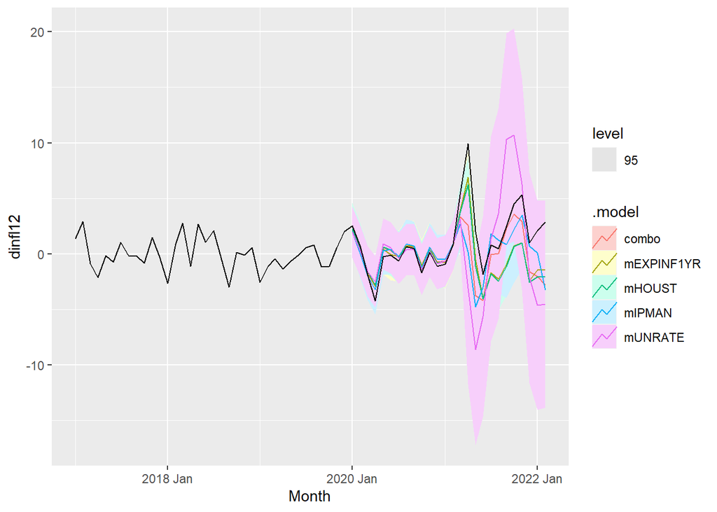

```r
fc_inflation <- fit_combo %>% forecast(new_data = test_data)
fc_inflation %>% autoplot(filter(clean_data, year(Month) > 2016), level = c(95))
```

# Accuracy

```r
test_accuracy <- accuracy(fc_inflation, clean_data) %>%
  select(c(".model", ".type", "MAPE")) %>%
  kable(format = "html", table.attr = "sytle='widtth:30%$;' ") %>%
  kableExtra::kable_styling()

test_accuracy
```

| .model | .type | MAPE |
| --- | --- | --- |
| combo | Test | 103.5577 |
| mEXPINF1YR | Test | 121.1259 |
| mHOUST | Test | 136.2762 |
| mIPMAN | Test | 107.7856 |
| mUNRATE | Test | 172.5794 |

# Conclusion

None of our models did a very good at predicting inflation. This is largely due to the fact that everything in the economy is interconnected. There are too many moving parts to be able to parse out one or two factors as explanatory predictors of another part of the economy. There may be a model out there that accurately predicts inflation, but no one has found it yet. We can confidently say that it is not any of these models.